# In 2009, we completed this project as part of our Post Graduate program, and it's fascinating to see how the mobile industry has undergone significant advancements since that time.

# Chapter 1

# Introduction

Mobile means that moves by itself. Mobile phones are becoming more and more common that life may be unimaginable without them .Carrying a mobile phone makes most people feel more secure, especially students when they are not with their parents. Our investigation will be to study whether this widespread use of mobile phones playing an important role in the student population or not.

Students use mobiles either it is a necessity or they can have a mobile or they are using for prestige etc. Our project mainly concentrates on that what factors influencing in selecting a handset, and to know that why students are using mobiles.

The usage of mobile is mainly based on two things one is handset and the other is service provider. Our survey considers these two in analyzing the mobile phone usage among stu- dents. The popular handset brands are NOKIA, LG, Samsung, Sony Ericsson and Motorola. And the popular service provider in Andhar Pradesh, India are Airtel, BSNL, idea, Vodafone, Reliance, Tata and Virgin.

Among handset brands NOKIA has larger market share and Airtel has larger market among service provider. Year by year the call charges and rentals are declining. This causes the increase of mobile usage. The handset costs are also declining then purchasing capacity increases. Usually the mobile usage population increases among students. Hence, we are interested to know that what makes a student select a mobile.

# 1.1 Objectives

1. To test whether there is any association between handset cost and income.
2. To test whether there is any association between monthly mobile expenditure and income.
3. What are the factors that influence the selection of a handset.
4. What for students are using mobile phones.

# 1.2 Sample selection

As the mobile using student population is very large we have selected different categories of students such as intermediate, degree, post graduates and research scholors. And our sample included both males and females, rural and urban of the above categories. The only criterion that a student will be included in the sample is that he should have a mobile. We approached students on their campuses and hostels. The questionnaire was given to the students who has mobiles after enquiring them whether they have a mobile or not. Even though we have not used any standard sampling technique it may be treated as random sample because the sample size is large and included different categories.

## Field and other experiences

### Unbalanced sample

Even though our sample included both males and females the proportion is not a balanced one. Male participants are more than two times of females. And various categories of students included in the sample, but the proportion of P.G. students is more than the others,the proportion of male students is greater than females and the proportion of rural students is greater than urban students.

### Design of questionnaire

In the design of questionnaire the variables meant for factor analysis are not enough for some questions. There are some ambiguous questions which are meant for factor analysis. Obviously some students felt inconvenience while responding to them.

### Lengthy questionnaire

Some students felt that they have spent much time in completing the questionnaire. And some students rejected to fill the questionnaire feeling that it will take more time. But we have included the questions which are necessary to this type of survey.

### Not aware of terminology and technology

Some of the students do not know the difference between handset and service provider. Some of them are not aware of such a modern features like bluetooth, camera pixels etc

### Participant’s nature

Most of the students filled questionnaire willingly and some of them seem to be participated just to fill it. Some of them gave valuable suggestions to us while proceeding for further survey and analysis.

# 1.3 Statistical Techniques And Packages

To analyze our data, we have used some statistical tools which can analyze our data as much as possible. The tools we have used are cross tables, statistics associated with cross tables and factor analysis. The software we have used to analyze the data is SPSS.

### 1.3.1 Cross tables

As our sample consists of number of variables and some of them measured simultaneously, then a naturally arising question is ”Is there any association among the variables.” To test the association among them we have used the concept of cross tables. Generally used test statistic to test the association among variables is Chi-square test of independence. This test can tell us whether there is an association or not. But it cannot give us any indication as to the direction of association or the strength of association. It can tell only whether there is association or not. We need to measure the strength and direction of association. There are some other test procedures to know the direction and strength of association. These procedures are classified into various groups depending on the measurement level of the variables. The nominal and ordinal measures are used to test the nominal and ordinal data respectively. As our data is ordinal in nature we have used such ordinal measures to test and measure the association. And they are described in the following chapter and some nominal measures also.

### 1.3.2 Factor analysis

Factor analysis describes the covariance relationships among several variables in terms of a few underlying unobservable random quantities called factors. Factor analysis can be considered as an extension of principal component analysis. Both the techniques attempt to approximate the covariance matrix. In factor analysis, we seek to account for the covariance or correlations among the variables. Dimension reduction and interpretation are two basic objectives of factor analysis. There are several methods that can be used to extract factors and the principal component method is one such method. We use this method for extracting factors. After factor extraction, we rotate the solution so that we can give some interpretation to the extracted factors. Again there are quite a number of rotation techniques available. These rotation techniques can be grouped into orthogonal and non-orthogonal. In the present context orthogonal rotation is appropriate. The method we have chosen is Varimax.

```python
import pandas as pd
import numpy as np
import matplotlib.pyplot as plt
import seaborn as sns

from scipy.stats import chi2_contingency

from tabulate import tabulate

#import scipy as spy
#import sklearn as sk
```

```python
pd.set_option('display.max_columns', None)
pd.set_option('display.max_rows', None)
```

```python
data = pd.read_csv('Project2009SPSS_to_CSV.csv')
```

```python
# Define a function to highlight a specific cell
# Define a function to highlight a specific cell
def highlight_cell(val):
    try:
        float_val = float(val)
        color = 'background-color: yellow' if float_val >= 0.6 else ''
    except ValueError:
        color = ''
    return color

# Apply the styling function to the DataFrame
#styled_df = your_dataframe.style.applymap(highlight_cell)
```

```python
data.head()
```

|  | Q1 | Q2 | Q3 | Q4 | Q5 | Q6 | Q7 | Q8 | Q9 | Q10 | Q11 | Q12 | Q13 | Q14 | Q15 | Q16 | Q17 | Q18 | Q19 | Q20 | Q21-1 | Q21-2 | Q21-3 | Q21-4 | Q21-5 | Q21-6 | Q21-7 | Q21-8 | Q22-1 | … |
| --- | --- | --- | --- | --- | --- | --- | --- | --- | --- | --- | --- | --- | --- | --- | --- | --- | --- | --- | --- | --- | --- | --- | --- | --- | --- | --- | --- | --- | --- | --- |
| 0 | 1 | 21 | 1 | 2 | 2 | 2 | 1 | 1 | 2 | 2 | 2 | 2 | 1 | 2 | 2 | 1 | 1 | 1 | 5 | 4 | 4 | 4 | 3 | 2 | 5 | 4 | 2 | 5 | 5 | … |
| 1 | 2 | 24 | 1 | 3 | 2 | 1 | 1 | 1 | 3 | 2 | 3 | 2 | 1 | 1 | 1 | 2 | 1 | 1 | 3 | 2 | 4 | 5 | 4 | 3 | 4 | 4 | 3 | 3 | 3 | … |
| 2 | 3 | 21 | 1 | 3 | 2 | 2 | 1 | 1 | 1 | 1 | 3 | 2 | 2 | 2 | 1 | 1 | 2 | 2 | 1 | 2 | 5 | 4 | 3 | 3 | 5 | 5 | 3 | 4 | 5 | … |
| 3 | 4 | 21 | 1 | 3 | 2 | 1 | 1 | 1 | 1 | 1 | 2 | 3 | 1 | 1 | 1 | 2 | 2 | 1 | 1 | 3 | 5 | 4 | 4 | 4 | 4 | 4 | 4 | 4 | 4 | … |
| 4 | 5 | 21 | 1 | 3 | 2 | 3 | 1 | 1 | 1 | 2 | 2 | 1 | 2 | 3 | 3 | 2 | 2 | 2 | 3 | 2 | 5 | 5 | 5 | 5 | 5 | 5 | 5 | 5 | 5 | … |

```python
data.info()
```

```
<class 'pandas.core.frame.DataFrame'>
RangeIndex: 527 entries, 0 to 526
Data columns (total 80 columns):
 #   Column  Non-Null Count  Dtype
---  ------  --------------  -----
 0   Q1      527 non-null    int64
 1   Q2      527 non-null    int64
 2   Q3      527 non-null    int64
 3   Q4      527 non-null    int64
 4   Q5      527 non-null    int64
 5   Q6      527 non-null    int64
 6   Q7      527 non-null    int64
 7   Q8      527 non-null    int64
 8   Q9      527 non-null    int64
 9   Q10     527 non-null    int64
```

[output cut: 72 more lines]

```python
qstns = pd.read_csv('Questionnaire.csv', encoding='latin-1')
#qstns.columns=None
qstns.head()
```

|  | Question_ID | Feature | Question |
| --- | --- | --- | --- |
| 0 | Q1 | Record_ID | Record_ID |
| 1 | Q2 | Age | Age |
| 2 | Q3 | Gender | Gender (Male/Female) |
| 3 | Q4 | Education | Educational Qualification - 1) Intermediate/eq... |
| 4 | Q5 | Father Occupation | Father occupation - 1) Coolie 2)Farmer 3)Self-... |

```python
qstns.iloc[:, 1]
```

```
0                                        Record_ID
1                                              Age
2                                           Gender
3                                        Education
4                                Father Occupation
5                                 Household Income
6                             Native (Rural/Urban)
7               Handset Type(Color/ Black & white)
8                                    Handset Brand
9                         Handset Selection Reason
10                                    Handset Cost
11                                     Handset Age
12                         Calls Receiving per day
13                           SMS Receiving per day
14                             SMS Sending per day
```

[output cut: 66 more lines]

```python
qstns.iloc[:, 2]
```

```
0                                             Record_ID
1                                                   Age
2                                  Gender (Male/Female)
3     Educational Qualification - 1) Intermediate/eq...
4     Father occupation - 1) Coolie 2)Farmer 3)Self-...
5     Household income per month - 1)<Rs.5000    2)R...
6                      Where are you from?(Rural/Urban)
7           Type of your handset?(Color/ Black & white)
8     Which brand of handset are you using currently...
9     What made you to select this handset? - 1)Bran...
10    How much price does your handset costs ? - 1)<...
11    Since how long you have been using this handse...
12    How many calls you receive per a day? - 1)<10 ...
13    How many SMS you receive per a day? - 1)<10 2)...
14    How many SMS you send per a day? - 1)<10 2)10-...
```

[output cut: 66 more lines]

```python
qstns['Feature']
```

```
0                                        Record_ID
1                                              Age
2                                           Gender
3                                        Education
4                                Father Occupation
5                                 Household Income
6                             Native (Rural/Urban)
7               Handset Type(Color/ Black & white)
8                                    Handset Brand
9                         Handset Selection Reason
10                                    Handset Cost
11                                     Handset Age
12                         Calls Receiving per day
13                           SMS Receiving per day
14                             SMS Sending per day
```

[output cut: 66 more lines]

```python
qstns['Question']
```

```
0                                             Record_ID
1                                                   Age
2                                  Gender (Male/Female)
3     Educational Qualification - 1) Intermediate/eq...
4     Father occupation - 1) Coolie 2)Farmer 3)Self-...
5     Household income per month - 1)<Rs.5000    2)R...
6                      Where are you from?(Rural/Urban)
7           Type of your handset?(Color/ Black & white)
8     Which brand of handset are you using currently...
9     What made you to select this handset? - 1)Bran...
10    How much price does your handset costs ? - 1)<...
11    Since how long you have been using this handse...
12    How many calls you receive per a day? - 1)<10 ...
13    How many SMS you receive per a day? - 1)<10 2)...
14    How many SMS you send per a day? - 1)<10 2)10-...
```

[output cut: 66 more lines]

```python
data.columns
```

```
Index(['Q1', 'Q2', 'Q3', 'Q4', 'Q5', 'Q6', 'Q7', 'Q8', 'Q9', 'Q10', 'Q11',
       'Q12', 'Q13', 'Q14', 'Q15', 'Q16', 'Q17', 'Q18', 'Q19', 'Q20', 'Q21-1',
       'Q21-2', 'Q21-3', 'Q21-4', 'Q21-5', 'Q21-6', 'Q21-7', 'Q21-8', 'Q22-1',
       'Q22-2', 'Q22-3', 'Q22-4', 'Q22-5', 'Q22-6', 'Q22-7', 'Q22-8', 'Q22-9',
       'Q22-10', 'Q22-11', 'Q22-12', 'Q22-13', 'Q22-14', 'Q22-15', 'Q22-16',
       'Q22-17', 'Q22-18', 'Q22-19', 'Q22-20', 'Q22-21', 'Q23-1', 'Q23-2',
       'Q23-3', 'Q23-4', 'Q23-5', 'Q23-6', 'Q23-7', 'Q23-8', 'Q23-9', 'Q23-10',
       'Q23-11', 'Q24-1', 'Q24-2', 'Q24-3', 'Q24-4', 'Q24-5', 'Q24-6', 'Q24-7',
       'Q25-1', 'Q25-2', 'Q25-3', 'Q25-4', 'Q25-5', 'Q25-6', 'Q25-7', 'Q25-8',
       'Q25-9', 'Q25-10', 'Q25-11', 'Q25-12', 'Q25-13'],
      dtype='object')
```

```python
data1 = data.copy()  # Create a copy of the original DataFrame
data1.columns = qstns['Feature']
data1.index.name = None
data1.head()
```

| Feature | Record_ID | Age | Gender | Education | Father Occupation | Household Income | Native (Rural/Urban) | Handset Type(Color/ Black & white) | Handset Brand | Handset Selection Reason | Handset Cost | Handset Age | Calls Receiving per day | SMS Receiving per day | SMS Sending per day | Frequent Communication Type | Feel safe and secure with mobile | Monthly Mobile Expenditure | Current Service Provider | Current Service Provider Age | SP - Influence Rating for Signal | SP - Influence Rating for Customer care | SP - Influence Rating for Electronic media | SP - Influence Rating for Hoardings | SP - Influence Rating for Friends | SP - Influence Rating for Family members | SP - Influence Rating for Print media | SP - Influence Rating for Call costs | HS - Influence Rating for Brand | … |
| --- | --- | --- | --- | --- | --- | --- | --- | --- | --- | --- | --- | --- | --- | --- | --- | --- | --- | --- | --- | --- | --- | --- | --- | --- | --- | --- | --- | --- | --- | --- |
| 0 | 1 | 21 | 1 | 2 | 2 | 2 | 1 | 1 | 2 | 2 | 2 | 2 | 1 | 2 | 2 | 1 | 1 | 1 | 5 | 4 | 4 | 4 | 3 | 2 | 5 | 4 | 2 | 5 | 5 | … |
| 1 | 2 | 24 | 1 | 3 | 2 | 1 | 1 | 1 | 3 | 2 | 3 | 2 | 1 | 1 | 1 | 2 | 1 | 1 | 3 | 2 | 4 | 5 | 4 | 3 | 4 | 4 | 3 | 3 | 3 | … |
| 2 | 3 | 21 | 1 | 3 | 2 | 2 | 1 | 1 | 1 | 1 | 3 | 2 | 2 | 2 | 1 | 1 | 2 | 2 | 1 | 2 | 5 | 4 | 3 | 3 | 5 | 5 | 3 | 4 | 5 | … |
| 3 | 4 | 21 | 1 | 3 | 2 | 1 | 1 | 1 | 1 | 1 | 2 | 3 | 1 | 1 | 1 | 2 | 2 | 1 | 1 | 3 | 5 | 4 | 4 | 4 | 4 | 4 | 4 | 4 | 4 | … |
| 4 | 5 | 21 | 1 | 3 | 2 | 3 | 1 | 1 | 1 | 2 | 2 | 1 | 2 | 3 | 3 | 2 | 2 | 2 | 3 | 2 | 5 | 5 | 5 | 5 | 5 | 5 | 5 | 5 | 5 | … |

```python
type(data1)
```

```
pandas.core.frame.DataFrame
```

```python
data1.columns
```

```
Index(['Record_ID', 'Age', 'Gender', 'Education', 'Father Occupation',
       'Household Income', 'Native (Rural/Urban)',
       'Handset Type(Color/ Black & white)', 'Handset Brand',
       'Handset Selection Reason', 'Handset Cost', 'Handset Age',
       'Calls Receiving per day', 'SMS Receiving per day',
       'SMS Sending per day', 'Frequent Communication Type',
       'Feel safe and secure with mobile', 'Monthly Mobile Expenditure',
       'Current Service Provider', 'Current Service Provider Age',
       'SP - Influence Rating for Signal',
       'SP - Influence Rating for Customer care',
       'SP - Influence Rating for Electronic media',
       'SP - Influence Rating for Hoardings',
       'SP - Influence Rating for Friends',
       'SP - Influence Rating for Family members',
       'SP - Influence Rating for Print media',
       'SP - Influence Rating for Call costs',
       'HS - Influence Rating for Brand',
       'HS - Influence Rating for Battery back up',
       'HS - Influence Rating for Keypad', 'HS - Influence Rating for Display',
       'HS - Influence Rating for Sound',
       'HS - Influence Rating for Size of the screen',
       'HS - Influence Rating for Electronic media',
       'HS - Influence Rating for Print media',
       'HS - Influence Rating for Hoardings',
       'HS - Influence Rating for Friends',
       'HS - Influence Rating for Family members',
       'HS - Influence Rating for Voice clarity',
       'HS - Influence Rating for MP3 facility',
       'HS - Influence Rating for Bluetooth',
       'HS - Influence Rating for Camera pixels',
       'HS - Influence Rating for FM radio', 'HS - Influence Rating for Games',
       'HS - Influence Rating for Video',
       'HS - Influence Rating for Memory size',
       'HS - Influence Rating for Price', 'HS - Influence Rating for Stylish',
       'Stylish Handset Brand', 'More Models Handset Brand',
       'User friendly Handset Brand', 'Reasonable prices Handset Brand',
       'Added features Handset Brand', 'Customer service Handset Brand',
       'Advertisements Handset Brand', 'Sales promotions Handset Brand',
       'Available service centers Handset Brand', 'Durability Handset Brand',
       'Overall, I like the Handset Brand', 'User friendly Service Provider',
       'Added features Service Provider', 'Customer service Service Provider',
       'Advertisements Service Provider', 'Sales promotions Service Provider',
       'Available service centers Service Provider',
       'Overall, I like Service Provider', 'All my friends use',
       'Old fashioned', 'Prestige', 'Secure', 'Show-off', 'Life style',
       'Communication', 'Facilities', 'Life easier', 'Call Friends and Family',
       'Mostly use SMS', 'Music or Videos', 'Games'],
      dtype='object', name='Feature')
```

```python
data1.describe()
```

| Feature | Record_ID | Age | Gender | Education | Father Occupation | Household Income | Native (Rural/Urban) | Handset Type(Color/ Black & white) | Handset Brand | Handset Selection Reason | Handset Cost | Handset Age | Calls Receiving per day | SMS Receiving per day | SMS Sending per day | Frequent Communication Type | Feel safe and secure with mobile | Monthly Mobile Expenditure | Current Service Provider | Current Service Provider Age | SP - Influence Rating for Signal | SP - Influence Rating for Customer care | SP - Influence Rating for Electronic media | SP - Influence Rating for Hoardings | SP - Influence Rating for Friends | SP - Influence Rating for Family members | SP - Influence Rating for Print media | SP - Influence Rating for Call costs | HS - Influence Rating for Brand | … |
| --- | --- | --- | --- | --- | --- | --- | --- | --- | --- | --- | --- | --- | --- | --- | --- | --- | --- | --- | --- | --- | --- | --- | --- | --- | --- | --- | --- | --- | --- | --- |
| count | 527.000000 | 527.000000 | 527.000000 | 527.000000 | 527.000000 | 527.000000 | 527.000000 | 527.000000 | 527.000000 | 527.000000 | 527.000000 | 527.000000 | 527.000000 | 527.000000 | 527.000000 | 527.000000 | 527.000000 | 527.000000 | 527.000000 | 527.000000 | 527.000000 | 527.000000 | 527.000000 | 527.000000 | 527.000000 | 527.000000 | 527.000000 | 527.000000 | 527.000000 | … |
| mean | 264.000000 | 22.013283 | 0.719165 | 2.715370 | 3.149905 | 2.146110 | 1.349146 | 1.259962 | 1.963947 | 2.318786 | 2.379507 | 2.891841 | 1.544592 | 1.755218 | 1.796964 | 1.326376 | 1.417457 | 1.411765 | 2.711575 | 3.017078 | 4.318786 | 3.963947 | 3.368121 | 3.218216 | 3.954459 | 3.973435 | 3.146110 | 3.745731 | 4.390892 | … |
| std | 152.276065 | 2.931054 | 0.449834 | 0.741627 | 1.351775 | 1.020465 | 0.500489 | 0.540006 | 1.316981 | 0.953724 | 0.929142 | 1.389008 | 0.714731 | 0.899327 | 1.006892 | 0.469332 | 0.505031 | 0.736923 | 1.617490 | 1.461057 | 0.787792 | 0.910767 | 1.115552 | 1.138595 | 0.940135 | 0.952910 | 1.130084 | 1.040919 | 0.741846 | … |
| min | 1.000000 | 16.000000 | 0.000000 | 1.000000 | 1.000000 | 1.000000 | 1.000000 | 1.000000 | 1.000000 | 1.000000 | 1.000000 | 1.000000 | 1.000000 | 1.000000 | 1.000000 | 1.000000 | 1.000000 | 1.000000 | 1.000000 | 1.000000 | 1.000000 | 1.000000 | 1.000000 | 1.000000 | 1.000000 | 1.000000 | 1.000000 | 1.000000 | 1.000000 | … |
| 25% | 132.500000 | 20.000000 | 0.000000 | 2.000000 | 2.000000 | 1.000000 | 1.000000 | 1.000000 | 1.000000 | 2.000000 | 2.000000 | 2.000000 | 1.000000 | 1.000000 | 1.000000 | 1.000000 | 1.000000 | 1.000000 | 1.000000 | 2.000000 | 4.000000 | 4.000000 | 3.000000 | 2.000000 | 3.000000 | 4.000000 | 2.000000 | 3.000000 | 4.000000 | … |
| 50% | 264.000000 | 22.000000 | 1.000000 | 3.000000 | 3.000000 | 2.000000 | 1.000000 | 1.000000 | 1.000000 | 2.000000 | 2.000000 | 3.000000 | 1.000000 | 2.000000 | 1.000000 | 1.000000 | 1.000000 | 1.000000 | 2.000000 | 3.000000 | 4.000000 | 4.000000 | 3.000000 | 3.000000 | 4.000000 | 4.000000 | 3.000000 | 4.000000 | 5.000000 | … |
| 75% | 395.500000 | 23.000000 | 1.000000 | 3.000000 | 4.000000 | 3.000000 | 2.000000 | 1.000000 | 3.000000 | 3.000000 | 3.000000 | 4.000000 | 2.000000 | 2.000000 | 2.000000 | 2.000000 | 2.000000 | 2.000000 | 4.000000 | 4.000000 | 5.000000 | 5.000000 | 4.000000 | 4.000000 | 5.000000 | 5.000000 | 4.000000 | 4.000000 | 5.000000 | … |
| max | 527.000000 | 33.000000 | 1.000000 | 4.000000 | 6.000000 | 5.000000 | 5.000000 | 5.000000 | 5.000000 | 4.000000 | 5.000000 | 6.000000 | 4.000000 | 4.000000 | 4.000000 | 2.000000 | 3.000000 | 4.000000 | 7.000000 | 6.000000 | 5.000000 | 5.000000 | 5.000000 | 5.000000 | 5.000000 | 5.000000 | 5.000000 | 5.000000 | 5.000000 | … |

```python
for column in data1.columns:
    print(f"Value counts for {column}:\n{data1[column].value_counts()}\n")
```

```
Value counts for Record_ID:
1      1
363    1
361    1
360    1
359    1
358    1
357    1
356    1
355    1
354    1
353    1
352    1
351    1
350    1
```

[output cut: 1160 more lines]

```python
data1.iloc[:, 1].unique()
```

```
array([21, 24, 22, 26, 28, 23, 25, 17, 29, 20, 30, 27, 33, 16, 18, 19],
      dtype=int64)
```

```python
grouped_data = data1.groupby('Education')['Education'].count()
```

```python
grouped_data
```

```
Education
1     34
2    139
3    297
4     57
Name: Education, dtype: int64
```

```python
data1.iloc[:,5].value_counts()
```

```
2    177
1    171
3    111
4     67
5      1
Name: Household Income, dtype: int64
```

```python
# Checking condition
condition = data1['Household Income'] >= 5

# Update values in the specified column based on the condition
data1.loc[condition, 'Household Income'] = 4  # Replace 'updated_value' with the value you want to set
```

```python
data1.iloc[:,10].value_counts()
```

```
2    223
3    143
1     89
4     70
5      2
Name: Handset Cost, dtype: int64
```

```python
# Checking condition
condition = data1['Household Income'] >= 5

# Update values in the specified column based on the condition
data1.loc[condition, 'Household Income'] = 4  # Replace 'updated_value' with the value you want to set
```

```python
data1[(data1.iloc[:,10]==5) & (data1.iloc[:,6]==2)]
```

| Feature | Record_ID | Age | Gender | Education | Father Occupation | Household Income | Native (Rural/Urban) | Handset Type(Color/ Black & white) | Handset Brand | Handset Selection Reason | Handset Cost | Handset Age | Calls Receiving per day | SMS Receiving per day | SMS Sending per day | Frequent Communication Type | Feel safe and secure with mobile | Monthly Mobile Expenditure | Current Service Provider | Current Service Provider Age | SP - Influence Rating for Signal | SP - Influence Rating for Customer care | SP - Influence Rating for Electronic media | SP - Influence Rating for Hoardings | SP - Influence Rating for Friends | SP - Influence Rating for Family members | SP - Influence Rating for Print media | SP - Influence Rating for Call costs | HS - Influence Rating for Brand | … |
| --- | --- | --- | --- | --- | --- | --- | --- | --- | --- | --- | --- | --- | --- | --- | --- | --- | --- | --- | --- | --- | --- | --- | --- | --- | --- | --- | --- | --- | --- | --- |
| 249 | 250 | 24 | 1 | 2 | 3 | 1 | 2 | 1 | 3 | 3 | 5 | 2 | 2 | 2 | 1 | 1 | 3 | 1 | 1 | 6 | 5 | 5 | 5 | 5 | 5 | 5 | 5 | 5 | 4 | … |

```python
# Your conditions
condition1 = (data1['Handset Cost'] == 5)
condition2 = (data1['Native (Rural/Urban)'] == 2)  # Add additional conditions as needed

# Update values in the specified column based on the conditions
data1.loc[condition1 & condition2, 'Handset Cost'] = 2  # Replace 'updated_value' with the value you want to set
```

```python
# Your conditions
condition1 = (data1['Handset Cost'] == 5)
condition2 = (data1['Native (Rural/Urban)'] == 1)  # Add additional conditions as needed

# Update values in the specified column based on the conditions
data1.loc[condition1 & condition2, 'Handset Cost'] = 3  # Replace 'updated_value' with the value you want to set
```

```python
data1.iloc[:,10].value_counts()
```

```
2    224
3    144
1     89
4     70
Name: Handset Cost, dtype: int64
```

```python
data1[(data1['Native (Rural/Urban)']>=3)]
```

| Feature | Record_ID | Age | Gender | Education | Father Occupation | Household Income | Native (Rural/Urban) | Handset Type(Color/ Black & white) | Handset Brand | Handset Selection Reason | Handset Cost | Handset Age | Calls Receiving per day | SMS Receiving per day | SMS Sending per day | Frequent Communication Type | Feel safe and secure with mobile | Monthly Mobile Expenditure | Current Service Provider | Current Service Provider Age | SP - Influence Rating for Signal | SP - Influence Rating for Customer care | SP - Influence Rating for Electronic media | SP - Influence Rating for Hoardings | SP - Influence Rating for Friends | SP - Influence Rating for Family members | SP - Influence Rating for Print media | SP - Influence Rating for Call costs | HS - Influence Rating for Brand | … |
| --- | --- | --- | --- | --- | --- | --- | --- | --- | --- | --- | --- | --- | --- | --- | --- | --- | --- | --- | --- | --- | --- | --- | --- | --- | --- | --- | --- | --- | --- | --- |
| 62 | 63 | 20 | 1 | 2 | 4 | 4 | 5 | 1 | 5 | 2 | 3 | 4 | 2 | 2 | 2 | 1 | 1 | 2 | 4 | 3 | 5 | 5 | 4 | 3 | 3 | 3 | 3 | 3 | 5 | … |

```python
# Checking condition
condition = data1['Native (Rural/Urban)'] >= 3

# Update values in the specified column based on the condition
data1.loc[condition, 'Native (Rural/Urban)'] = 2  # Replace 'updated_value' with the value you want to set
```

```python
data1['Native (Rural/Urban)'].value_counts()
```

```
1    346
2    181
Name: Native (Rural/Urban), dtype: int64
```

```python
data1[(data1['Frequent Communication Type']>=2)].head()
```

| Feature | Record_ID | Age | Gender | Education | Father Occupation | Household Income | Native (Rural/Urban) | Handset Type(Color/ Black & white) | Handset Brand | Handset Selection Reason | Handset Cost | Handset Age | Calls Receiving per day | SMS Receiving per day | SMS Sending per day | Frequent Communication Type | Feel safe and secure with mobile | Monthly Mobile Expenditure | Current Service Provider | Current Service Provider Age | SP - Influence Rating for Signal | SP - Influence Rating for Customer care | SP - Influence Rating for Electronic media | SP - Influence Rating for Hoardings | SP - Influence Rating for Friends | SP - Influence Rating for Family members | SP - Influence Rating for Print media | SP - Influence Rating for Call costs | HS - Influence Rating for Brand | … |
| --- | --- | --- | --- | --- | --- | --- | --- | --- | --- | --- | --- | --- | --- | --- | --- | --- | --- | --- | --- | --- | --- | --- | --- | --- | --- | --- | --- | --- | --- | --- |
| 1 | 2 | 24 | 1 | 3 | 2 | 1 | 1 | 1 | 3 | 2 | 3 | 2 | 1 | 1 | 1 | 2 | 1 | 1 | 3 | 2 | 4 | 5 | 4 | 3 | 4 | 4 | 3 | 3 | 3 | … |
| 3 | 4 | 21 | 1 | 3 | 2 | 1 | 1 | 1 | 1 | 1 | 2 | 3 | 1 | 1 | 1 | 2 | 2 | 1 | 1 | 3 | 5 | 4 | 4 | 4 | 4 | 4 | 4 | 4 | 4 | … |
| 4 | 5 | 21 | 1 | 3 | 2 | 3 | 1 | 1 | 1 | 2 | 2 | 1 | 2 | 3 | 3 | 2 | 2 | 2 | 3 | 2 | 5 | 5 | 5 | 5 | 5 | 5 | 5 | 5 | 5 | … |
| 5 | 6 | 22 | 1 | 3 | 3 | 1 | 1 | 1 | 2 | 2 | 3 | 3 | 1 | 2 | 3 | 2 | 1 | 1 | 4 | 2 | 4 | 5 | 4 | 3 | 5 | 5 | 3 | 4 | 5 | … |
| 9 | 10 | 22 | 1 | 2 | 4 | 3 | 1 | 1 | 4 | 2 | 3 | 3 | 2 | 2 | 2 | 2 | 1 | 1 | 3 | 3 | 5 | 5 | 3 | 3 | 5 | 5 | 3 | 4 | 4 | … |

```python
# Checking condition
condition = data1['Frequent Communication Type'] >= 3

# Update values in the specified column based on the condition
data1.loc[condition, 'Frequent Communication Type'] = 2  # Replace 'updated_value' with the value you want to set
```

```python
data1['Frequent Communication Type'].value_counts()
```

```
1    355
2    172
Name: Frequent Communication Type, dtype: int64
```

```python
data1[(data1['Feel safe and secure with mobile']>=3)]
```

| Feature | Record_ID | Age | Gender | Education | Father Occupation | Household Income | Native (Rural/Urban) | Handset Type(Color/ Black & white) | Handset Brand | Handset Selection Reason | Handset Cost | Handset Age | Calls Receiving per day | SMS Receiving per day | SMS Sending per day | Frequent Communication Type | Feel safe and secure with mobile | Monthly Mobile Expenditure | Current Service Provider | Current Service Provider Age | SP - Influence Rating for Signal | SP - Influence Rating for Customer care | SP - Influence Rating for Electronic media | SP - Influence Rating for Hoardings | SP - Influence Rating for Friends | SP - Influence Rating for Family members | SP - Influence Rating for Print media | SP - Influence Rating for Call costs | HS - Influence Rating for Brand | … |
| --- | --- | --- | --- | --- | --- | --- | --- | --- | --- | --- | --- | --- | --- | --- | --- | --- | --- | --- | --- | --- | --- | --- | --- | --- | --- | --- | --- | --- | --- | --- |
| 249 | 250 | 24 | 1 | 2 | 3 | 1 | 2 | 1 | 3 | 3 | 2 | 2 | 2 | 2 | 1 | 1 | 3 | 1 | 1 | 6 | 5 | 5 | 5 | 5 | 5 | 5 | 5 | 5 | 4 | … |
| 275 | 276 | 21 | 0 | 4 | 3 | 2 | 1 | 1 | 1 | 3 | 2 | 1 | 1 | 1 | 2 | 1 | 3 | 1 | 1 | 2 | 5 | 4 | 3 | 4 | 4 | 4 | 5 | 4 | 5 | … |
| 480 | 481 | 25 | 1 | 3 | 1 | 1 | 1 | 2 | 1 | 1 | 1 | 1 | 1 | 1 | 1 | 1 | 3 | 1 | 1 | 1 | 5 | 4 | 3 | 2 | 3 | 5 | 2 | 4 | 4 | … |

```python
# Checking condition
condition = data1['Feel safe and secure with mobile'] >= 3

# Update values in the specified column based on the condition
data1.loc[condition, 'Feel safe and secure with mobile'] = 2  # Replace 'updated_value' with the value you want to set
```

```python
data1['Handset Type(Color/ Black & white)'].value_counts()
```

```
1    405
2    115
5      3
4      2
3      2
Name: Handset Type(Color/ Black & white), dtype: int64
```

```python
data1[(data1['Handset Type(Color/ Black & white)']>=3)]
```

| Feature | Record_ID | Age | Gender | Education | Father Occupation | Household Income | Native (Rural/Urban) | Handset Type(Color/ Black & white) | Handset Brand | Handset Selection Reason | Handset Cost | Handset Age | Calls Receiving per day | SMS Receiving per day | SMS Sending per day | Frequent Communication Type | Feel safe and secure with mobile | Monthly Mobile Expenditure | Current Service Provider | Current Service Provider Age | SP - Influence Rating for Signal | SP - Influence Rating for Customer care | SP - Influence Rating for Electronic media | SP - Influence Rating for Hoardings | SP - Influence Rating for Friends | SP - Influence Rating for Family members | SP - Influence Rating for Print media | SP - Influence Rating for Call costs | HS - Influence Rating for Brand | … |
| --- | --- | --- | --- | --- | --- | --- | --- | --- | --- | --- | --- | --- | --- | --- | --- | --- | --- | --- | --- | --- | --- | --- | --- | --- | --- | --- | --- | --- | --- | --- |
| 58 | 59 | 22 | 1 | 3 | 2 | 1 | 1 | 4 | 1 | 4 | 4 | 2 | 2 | 2 | 3 | 2 | 1 | 2 | 1 | 4 | 5 | 5 | 3 | 4 | 5 | 4 | 3 | 3 | 5 | … |
| 81 | 82 | 25 | 1 | 3 | 2 | 3 | 1 | 3 | 1 | 3 | 1 | 3 | 1 | 2 | 3 | 2 | 1 | 1 | 7 | 1 | 3 | 3 | 3 | 4 | 3 | 4 | 3 | 4 | 3 | … |
| 193 | 194 | 17 | 1 | 1 | 4 | 4 | 2 | 5 | 1 | 1 | 4 | 3 | 2 | 2 | 2 | 1 | 1 | 2 | 4 | 3 | 5 | 5 | 5 | 5 | 5 | 5 | 5 | 5 | 5 | … |
| 239 | 240 | 22 | 0 | 3 | 6 | 2 | 1 | 4 | 3 | 4 | 3 | 3 | 2 | 2 | 3 | 2 | 1 | 1 | 1 | 3 | 4 | 4 | 2 | 2 | 4 | 4 | 2 | 2 | 4 | … |
| 245 | 246 | 29 | 1 | 2 | 4 | 2 | 2 | 3 | 3 | 4 | 4 | 2 | 2 | 2 | 2 | 1 | 1 | 4 | 4 | 3 | 4 | 4 | 4 | 4 | 4 | 4 | 4 | 4 | 3 | … |
| 394 | 395 | 23 | 1 | 3 | 5 | 3 | 1 | 5 | 2 | 2 | 3 | 2 | 1 | 1 | 1 | 1 | 2 | 1 | 1 | 3 | 5 | 5 | 1 | 1 | 4 | 5 | 1 | 4 | 5 | … |
| 472 | 473 | 23 | 1 | 3 | 2 | 1 | 1 | 5 | 4 | 2 | 3 | 3 | 4 | 4 | 1 | 1 | 2 | 1 | 5 | 6 | 5 | 3 | 2 | 2 | 4 | 4 | 2 | 4 | 5 | … |

```python
# Checking condition
condition = data1['Handset Type(Color/ Black & white)'] >= 3

# Update values in the specified column based on the condition
data1.loc[condition, 'Handset Type(Color/ Black & white)'] = 2  # Replace 'updated_value' with the value you want to set
```

```python
data1['Handset Type(Color/ Black & white)'].value_counts()
```

```
1    405
2    122
Name: Handset Type(Color/ Black & white), dtype: int64
```

```python
grouped_data = data1.groupby('Education')['Education'].count()
```

```python
print(grouped_data)
```

```
Education
1     34
2    139
3    297
4     57
Name: Education, dtype: int64
```

```python
for column in data1.columns:
    print(f"Value counts for {column}:\n{data1[column].value_counts()}\n")
```

```
Value counts for Record_ID:
1      1
363    1
361    1
360    1
359    1
358    1
357    1
356    1
355    1
354    1
353    1
352    1
351    1
350    1
```

[output cut: 1153 more lines]

```python
# Mapping dictionary for reverse coding

#Educational Qualification - 1) Intermediate/equivalent 2)U.G.   3)P.G. 4)Research scholars

Gender_Code = {
    1: 'Male',
    0: 'Female'
}

Edu_Code = {
    1: '1-Intermediate/equivalent',
    2: '2-U.G.',
    3: '3-P.G.',
    4: '4-Research scholars'
}

#Father occupation - 1) Coolie 2)Farmer 3)Self- Employed 4)Employee 5)Business 6)Others

Parent_Occu_Code = {
    1: '1-Coolie',
    2: '2-Farmer',
    3: '3-Self-Employed',
    4: '4-Employee',
    5: '5-Business',
    6: '6-Others'
}

#Household income per month - 1)<Rs.5000    2)Rs.5000-10000     3)Rs.10000-15000 4)>15000

Household_Income_Code = {
    1: '1-<Rs.5000',
    2: '2-Rs.5000-10000',
    3: '3-Rs.10000-15000',
    4: '4->15000'
}

#Native (Rural/Urban)	Where are you from?(Rural/Urban)


Nativity_Code = {
    1: 'Rural',
    2: 'Urban'
}

#Which brand of handset are you using currently? - 1)Nokia 2)L.G. 3)Samsung 4)Sony Ericsson  5)Motorola

Handset_Brand_Code = {
    1: 'Nokia',
    2: 'L.G.',
    3: 'Samsung',
    4: 'Sony Ericsson',
    5: 'Motorola'
}

#What made you to select this handset? - 1)Brand reputation 2)Satisfactory features  3)Servicing facilities    4)Price

Handset_Selection_Code = {
    1: 'Brand reputation',
    2: 'Satisfactory features',
    3: 'Servicing facilities',
    4: 'Price'
}

#How much price does your handset costs ? - 1)<Rs.1500   2)Rs.1500-2500      3)Rs.2500-5000       4)>Rs.5000

Handset_Cost_Code = {
    1: '1-<Rs.1500',
    2: '2-Rs.1500-2500',
    3: '3-Rs.2500-5000',
    4: '4->Rs.5000'
}

#Since how long you have been using this handset? -
# 1)0-6 months  2)6-12 months  3)1-2 years  4)2-3 years  5)3-4 years  6)>4 years

Handset_Age_Code = {
    1: '1: 0-6 months',
    2: '2: 6-12 months',
    3: '3: 1-2 years',
    4: '4: 2-3 years',
    5: '5: 3-4 years',
    6: '6: >4 years'
}

#Calls Receiving per day	How many calls you receive per a day? - 1)<10 2)10-25 3)25-50 4)>50
Calls_Rec_Code = {
    1: '1: <10',
    2: '2: 10-25',
    3: '3: 25-50',
    4: '4: >50'
}

#SMS Receiving per day	How many SMS you receive per a day? - 1)<10 2)10-25 3)25-50 4)>50
SMS_Rec_Code = {
    1: '1: <10',
    2: '2: 10-25',
    3: '3: 25-50',
    4: '4: >50'
}

#SMS Sending per day	How many SMS you send per a day? - 1)<10 2)10-25 3)25-50 4)>50
SMS_Send_Code = {
    1: '1: <10',
    2: '2: 10-25',
    3: '3: 25-50',
    4: '4: >50'
}

#Monthly Mobile Expenditure - How much you are spending towards mobile per month? -
# 1)<Rs.300 2)Rs.300-500 3)Rs.500-1000 4)>Rs.1000

Mobile_Expend_Code = {
    1: '1-<Rs.300',
    2: '2-Rs.300-500',
    3: '3-Rs.500-1000',
    4: '4->Rs.1000'
}

#Current Service Provider - Which service provider do you use currently? -
# 1)Airtel     2)BSNL     3)Idea     4)Vodafone 5)Reliance    6)Tata    7)Virgin

Service_Provider_Code = {
    1: 'Airtel',
    2: 'BSNL',
    3: 'Idea',
    4: 'Vodafone',
    5: 'Reliance',
    6: 'Tata',
    7: 'Virgin'
}

#Current Service Provider Age	How long you have been using this service provider? -
# 1)0-6 months  2)6-12 months  3)1-2 years  4)2-3 years  5)3-4 years  6)>4 years

Service_Provider_Age_Code = {
    1: '1: 0-6 months',
    2: '2: 6-12 months',
    3: '3: 1-2 years',
    4: '4: 2-3 years',
    5: '5: 3-4 years',
    6: '6: >4 years'
}
```

```python
type(Edu_Code)
```

```
dict
```

```python
Edu_Code
```

```
{1: '1-Intermediate/equivalent',
 2: '2-U.G.',
 3: '3-P.G.',
 4: '4-Research scholars'}
```

```python
data1['Education'].map(Edu_Code)
```

```
0                         2-U.G.
1                         3-P.G.
2                         3-P.G.
3                         3-P.G.
4                         3-P.G.
5                         3-P.G.
6                         3-P.G.
7                         3-P.G.
8                         3-P.G.
9                         2-U.G.
10                        3-P.G.
11                        2-U.G.
12                        3-P.G.
13                        3-P.G.
14                        3-P.G.
```

[output cut: 513 more lines]

```python
data1['Education'].map(Edu_Code).value_counts()
```

```
3-P.G.                       297
2-U.G.                       139
4-Research scholars           57
1-Intermediate/equivalent     34
Name: Education, dtype: int64
```

```python
#Creating a new dataframe to reverse code some features
data2 = data1.copy()  # Create a copy of the original DataFrame
data2.head()
```

| Feature | Record_ID | Age | Gender | Education | Father Occupation | Household Income | Native (Rural/Urban) | Handset Type(Color/ Black & white) | Handset Brand | Handset Selection Reason | Handset Cost | Handset Age | Calls Receiving per day | SMS Receiving per day | SMS Sending per day | Frequent Communication Type | Feel safe and secure with mobile | Monthly Mobile Expenditure | Current Service Provider | Current Service Provider Age | SP - Influence Rating for Signal | SP - Influence Rating for Customer care | SP - Influence Rating for Electronic media | SP - Influence Rating for Hoardings | SP - Influence Rating for Friends | SP - Influence Rating for Family members | SP - Influence Rating for Print media | SP - Influence Rating for Call costs | HS - Influence Rating for Brand | … |
| --- | --- | --- | --- | --- | --- | --- | --- | --- | --- | --- | --- | --- | --- | --- | --- | --- | --- | --- | --- | --- | --- | --- | --- | --- | --- | --- | --- | --- | --- | --- |
| 0 | 1 | 21 | 1 | 2 | 2 | 2 | 1 | 1 | 2 | 2 | 2 | 2 | 1 | 2 | 2 | 1 | 1 | 1 | 5 | 4 | 4 | 4 | 3 | 2 | 5 | 4 | 2 | 5 | 5 | … |
| 1 | 2 | 24 | 1 | 3 | 2 | 1 | 1 | 1 | 3 | 2 | 3 | 2 | 1 | 1 | 1 | 2 | 1 | 1 | 3 | 2 | 4 | 5 | 4 | 3 | 4 | 4 | 3 | 3 | 3 | … |
| 2 | 3 | 21 | 1 | 3 | 2 | 2 | 1 | 1 | 1 | 1 | 3 | 2 | 2 | 2 | 1 | 1 | 2 | 2 | 1 | 2 | 5 | 4 | 3 | 3 | 5 | 5 | 3 | 4 | 5 | … |
| 3 | 4 | 21 | 1 | 3 | 2 | 1 | 1 | 1 | 1 | 1 | 2 | 3 | 1 | 1 | 1 | 2 | 2 | 1 | 1 | 3 | 5 | 4 | 4 | 4 | 4 | 4 | 4 | 4 | 4 | … |
| 4 | 5 | 21 | 1 | 3 | 2 | 3 | 1 | 1 | 1 | 2 | 2 | 1 | 2 | 3 | 3 | 2 | 2 | 2 | 3 | 2 | 5 | 5 | 5 | 5 | 5 | 5 | 5 | 5 | 5 | … |

```python
#Creating a new dataframe to reverse code some features

data2['Gender']=data2['Gender'].map(Gender_Code)
data2['Education']=data2['Education'].map(Edu_Code)
data2['Father Occupation']=data2['Father Occupation'].map(Parent_Occu_Code)
data2['Household Income']=data2['Household Income'].map(Household_Income_Code)
data2['Native (Rural/Urban)']=data2['Native (Rural/Urban)'].map(Nativity_Code)
data2['Handset Brand']=data2['Handset Brand'].map(Handset_Brand_Code)
data2['Handset Selection Reason']=data2['Handset Selection Reason'].map(Handset_Selection_Code)
data2['Handset Cost']=data2['Handset Cost'].map(Handset_Cost_Code)
data2['Handset Age']=data2['Handset Age'].map(Handset_Age_Code)
data2['Calls Receiving per day']=data2['Calls Receiving per day'].map(Calls_Rec_Code)
data2['SMS Receiving per day']=data2['SMS Receiving per day'].map(SMS_Rec_Code)
data2['SMS Sending per day']=data2['SMS Sending per day'].map(SMS_Send_Code)
data2['Monthly Mobile Expenditure']=data2['Monthly Mobile Expenditure'].map(Mobile_Expend_Code)
data2['Current Service Provider']=data2['Current Service Provider'].map(Service_Provider_Code)
data2['Current Service Provider Age']=data2['Current Service Provider Age'].map(Service_Provider_Age_Code)
```

```
(array([0, 1, 2, 3]),
 [Text(0, 0, '2-U.G.'),
```

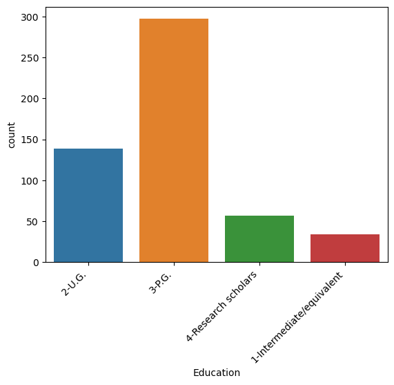

```python
sns.countplot(x='Education',data=data2)
plt.xticks( rotation=45, ha='right')  # Adjust rotation and ha as needed
```

```
(array([0, 1, 2, 3]),
 [Text(0, 0, '2-U.G.'),
```

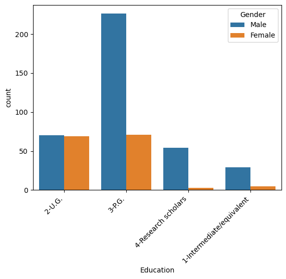

```python
sns.countplot(x='Education'
              ,data=data2
              ,hue='Gender')
plt.xticks( rotation=45, ha='right')  # Adjust rotation and ha as needed
```

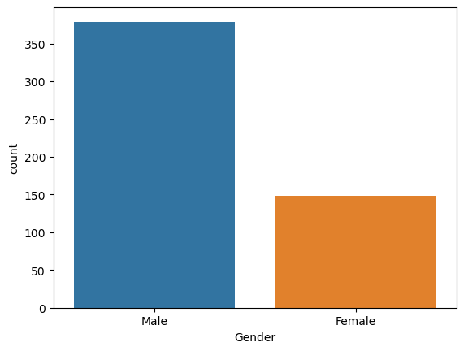

```python
sns.countplot(x='Gender'
              ,data=data2)
```

```python
data2.iloc[:,4].value_counts()
```

```
2-Farmer           204
4-Employee         162
5-Business          63
3-Self-Employed     38
1-Coolie            37
6-Others            23
Name: Father Occupation, dtype: int64
```

```python
data2.iloc[:,4].map(Parent_Occu_Code).value_counts()
```

```
Series([], Name: Father Occupation, dtype: int64)
```

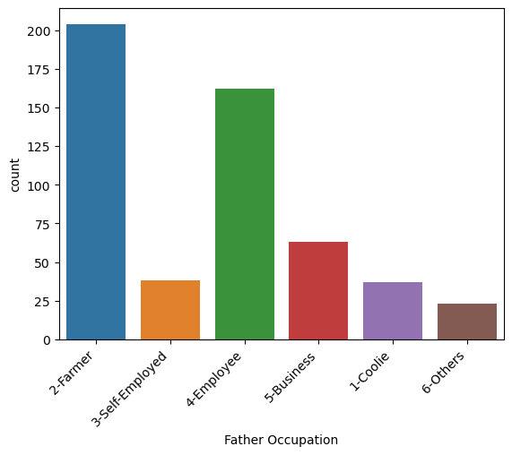

```python
sns.countplot(x='Father Occupation'
              ,data=data2
              )

plt.xticks( rotation=45, ha='right')  # Adjust rotation and ha as needed
plt.show()
```

```
(array([0, 1, 2, 3]),
 [Text(0, 0, '2-Rs.5000-10000'),
```

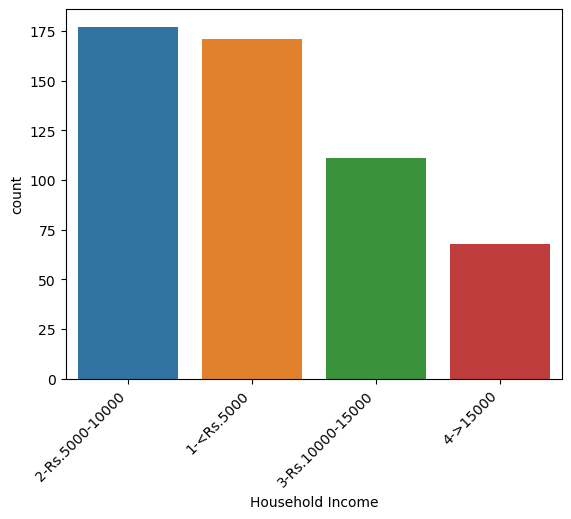

```python
sns.countplot(x='Household Income'
              ,data=data2)
plt.xticks( rotation=45, ha='right')  # Adjust rotation and ha as needed
```

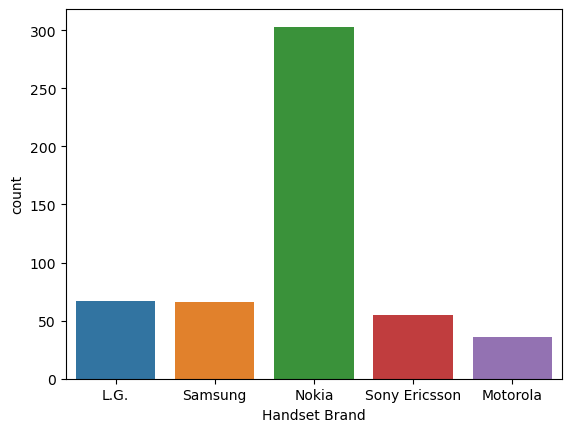

```python
sns.countplot(x='Handset Brand'
              ,data=data2)
```

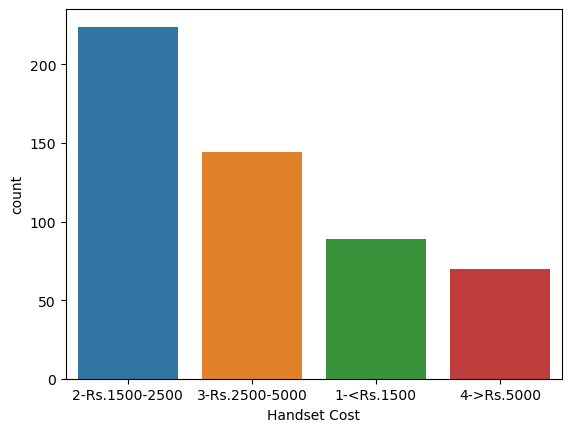

```python
sns.countplot(x='Handset Cost'
              ,data=data2)
```

```python
Handset_cost = pd.DataFrame(data2.groupby('Handset Cost')['Handset Cost'].count())
Handset_cost['Handset cost%']=Handset_cost['Handset Cost']/Handset_cost['Handset Cost'].sum()*100

Handset_cost
```

| Handset Cost | Handset Cost | Handset cost% |
| --- | --- | --- |
| 1-<Rs.1500 | 89 | 16.888046 |
| 2-Rs.1500-2500 | 224 | 42.504744 |
| 3-Rs.2500-5000 | 144 | 27.324478 |
| 4->Rs.5000 | 70 | 13.282732 |

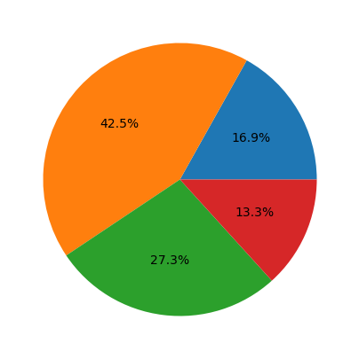

```python
plt.figure(figsize=(5,5))
plt.pie(Handset_cost['Handset Cost'], autopct="%1.1f%%")
plt.show()
```

```python
Handset_cost2=data2.dropna(subset=["Handset Cost"])
Handset_cost2=data2.groupby("Handset Cost")
Handset_cost21 = Handset_cost2.size().sort_values(ascending = False)
Handset_cost21 = Handset_cost21.to_frame('Count').reset_index()
Handset_cost21['Handset Cost %']=Handset_cost21['Count']/Handset_cost21['Count'].sum()*100

Handset_cost21
Handset_cost21.head(10)
```

|  | Handset Cost | Count | Handset Cost % |
| --- | --- | --- | --- |
| 0 | 2-Rs.1500-2500 | 224 | 42.504744 |
| 1 | 3-Rs.2500-5000 | 144 | 27.324478 |
| 2 | 1-<Rs.1500 | 89 | 16.888046 |
| 3 | 4->Rs.5000 | 70 | 13.282732 |

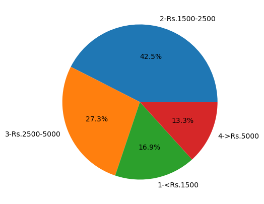

```python
plt.figure(figsize=(5,5))
plt.pie(Handset_cost21['Count'],labels=Handset_cost21["Handset Cost"], autopct="%1.1f%%")
plt.show()
```

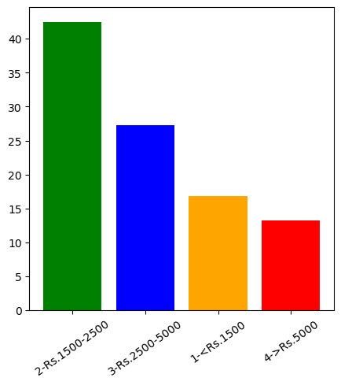

```python
plt.figure(figsize=(5,5))
colors = ['green', 'blue', 'orange', 'red', 'yellow', 'indigo']

#plt.bar(x=Handset_cost21["Handset Cost"].map(Handset_Cost_Code),height=Handset_cost21['Handset Cost %'],color=colors)
plt.bar(x=Handset_cost21["Handset Cost"],height=Handset_cost21['Handset Cost %'],color=colors
       )

# Set x-axis tick positions and labels
#plt.xticks(Handset_cost21["Handset Cost"], labels=Handset_cost21["Handset Cost"].map(Handset_Cost_Code),rotation=35)

plt.xticks(rotation=35)

#plt.legend()
# plt.xlabel('Handset Cost')
# plt.ylabel('Handset Cost Percentage')
# plt.title('Handset Cost Distribution')

plt.show()
```

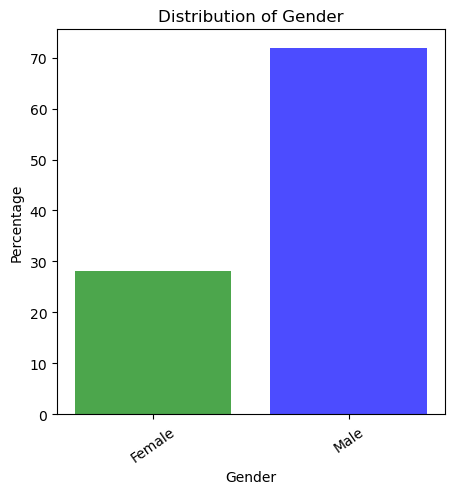

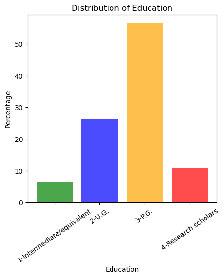

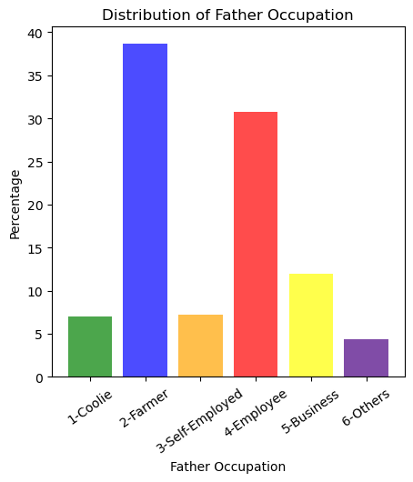

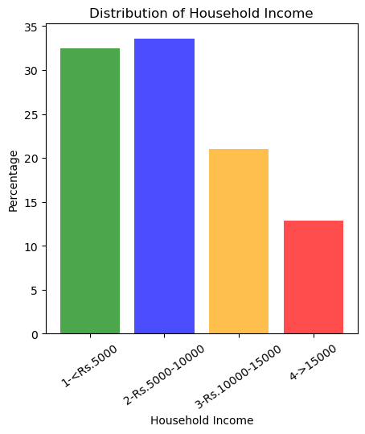

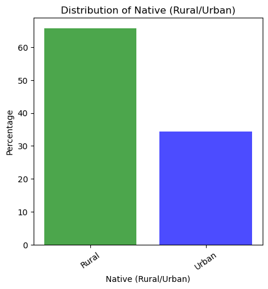

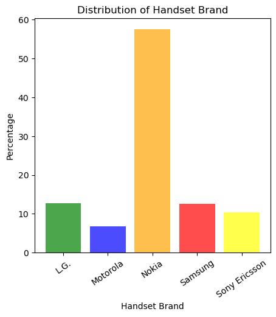

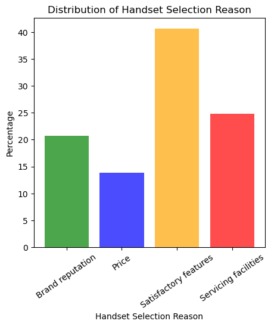

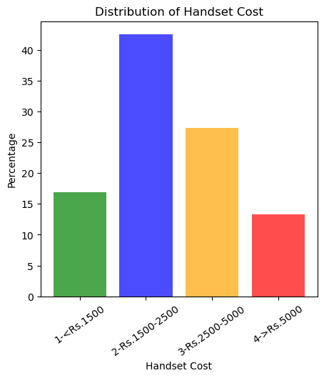

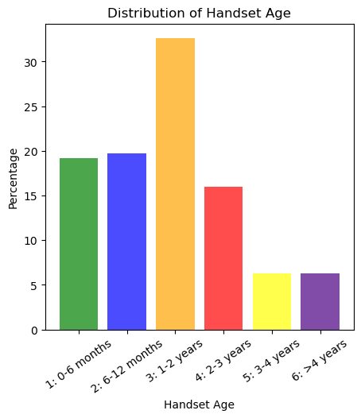

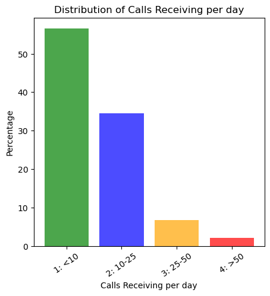

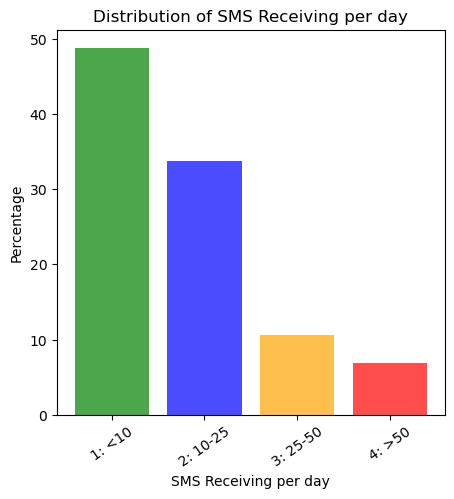

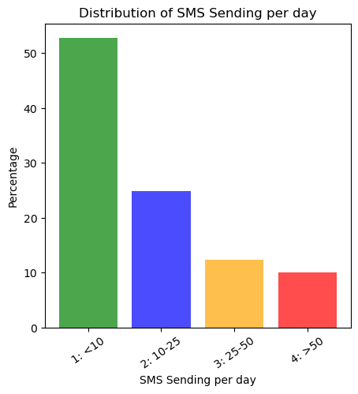

[3 more figures not shown]

```python
# Assuming 'data2' is your DataFrame
columns_of_interest = [ 'Gender', 'Education', 'Father Occupation',
       'Household Income','Native (Rural/Urban)', 'Handset Brand',
       'Handset Selection Reason', 'Handset Cost', 'Handset Age',
       'Calls Receiving per day', 'SMS Receiving per day',
       'SMS Sending per day',  'Monthly Mobile Expenditure',
       'Current Service Provider', 'Current Service Provider Age',]

for column in columns_of_interest:
    # Drop NaN values and group by the specified column
    data2[column] = data2[column].astype('category')
    grouped_data = data2.dropna(subset=[column]).groupby(column)

    # Create a DataFrame with counts and percentages
    data_grouped = grouped_data.size().to_frame('Count').reset_index()
    data_grouped['Percentage'] = data_grouped['Count'] / data_grouped['Count'].sum() * 100

    # Sort the DataFrame by the column of interest
    data_grouped = data_grouped.sort_values(by=column, ascending=True)

    # Plot the bar chart
    plt.figure(figsize=(5, 5))
    colors = ['green', 'blue', 'orange', 'red', 'yellow', 'indigo','cyan']

    plt.bar(x=data_grouped[column], height=data_grouped['Percentage'], color=colors, alpha=0.7)
    plt.xticks(range(len(data_grouped)), rotation=35)
    plt.xlabel(column)
    plt.ylabel('Percentage')
    plt.title(f'Distribution of {column}')
    plt.show()
```